# 데이터 과학 – 기초 통계

장효조, 김태균 누가 더 타율이 높은가?

## 1. 베이지안 A/B 검정 [^1]

2011년 젊은 나이에 위암투병 후 세상을 떠난 [장효조](https://ko.wikipedia.org/wiki/%EC%9E%A5%ED%9A%A8%EC%A1%B0) 선수와 일본에서 돌아와 여전히 현역으로 수위타자를 넘보고 있는 김태균 선수 중 누가 더 우수한 선수인가? 이런 질문은 야구에 관심이 있거나, 사자와 호랑이가 싸우면 누가 이기나? 마징가와 건담이 싸우면 누가 이길까? 이런 질문이 될 수도 있지만, 야구 데이터를 가지고 최고 타자를 검증해보자.

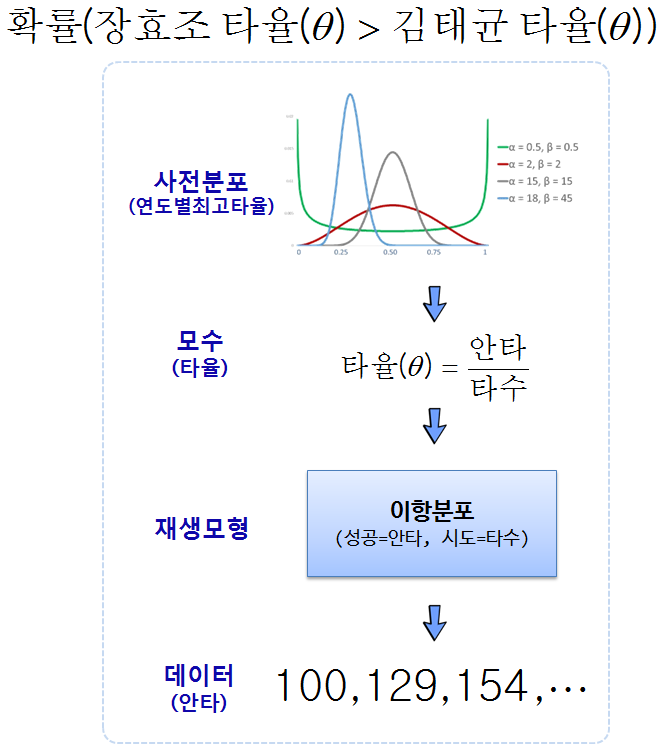

결국, 장효조 선수의 타율이 김태균 선수 타율보다 높은 확률이 얼마인가를 가지고, 특정 확률값 예를 들어 70% 이상 되면 역대 최고 타자로 장효조 선수를 인정하는 것으로 정리하는 것도 한 방법이다.

사전분포는 82년부터 [연도별 최고타율](https://ko.wikipedia.org/wiki/KBO_%EB%A6%AC%EA%B7%B8_%ED%83%80%EC%9C%A8_%EA%B4%80%EB%A0%A8_%EA%B8%B0%EB%A1%9D)을 획득한 선수의 타율을 사전분포로 두고 베타분포의 모수 $\alpha , \beta$를 추정하고, 이를 장효조, 김태균 선수의 타율과 결합하여 사후분포를 추정하여 누가 더 타율이 좋은지 평가한다.

## 2. 단계별 베이지안 검정

### 2.1. 데이터 가져오기

베이지안 데이터 분석에 필요한 팩키지를 가져와서 설치한다. 장효조, 김태균 선수 야구기록을 위키에서 긁어와서 데이터프레임으로 준비한다.

```r
# 0. 환경설정 -------------------------------------------
# list_of_packages <- c("ggplot2", "tidyverse", "ggthemes", "pwr", "extrafont", "shiny", "broom",
#                       "tibble", "rvest", "stringr", "extrafont")
# new_packages <- list_of_packages[!(list_of_packages %in% installed.packages()[,"Package"])]
# if(length(new_packages)) install.packages(new_packages)
#
# sapply(list_of_packages, require, character.only = TRUE)

# 1. 대한민국 최고 타자 데이터 --------------------------
## 1.1. 타자 장효조 -------------------------------------
Sys.setlocale("LC_ALL", "English")
```

```
[1] "LC_COLLATE=English_United States.1252;LC_CTYPE=English_United States.1252;LC_MONETARY=English_United States.1252;LC_NUMERIC=C;LC_TIME=English_United States.1252"
```

```r
chj_url <- "https://ko.wikipedia.org/wiki/%EC%9E%A5%ED%9A%A8%EC%A1%B0"
chj_xml <- read_html(chj_url)

chj_tbl <- html_nodes(chj_xml, xpath='//*[@id="mw-content-text"]/div/table[3]')
chj_tbl <- html_table(chj_tbl, fill=TRUE)[[1]]

Sys.setlocale("LC_ALL", "Korean")
```

```
[1] "LC_COLLATE=Korean_Korea.949;LC_CTYPE=Korean_Korea.949;LC_MONETARY=Korean_Korea.949;LC_NUMERIC=C;LC_TIME=Korean_Korea.949"
```

```r
DT::datatable(chj_tbl)
```

|  | 연 도 | 소 속 | 나 이 | 출 장 | 타 석 | 타 수 | 득 점 | 안 타 | 2 루 타 | 3 루 타 | 홈 런 | 타 점 | 도 루 | 도 실 | 볼 넷 | 삼 진 | 타 율 | 출 루 율 | 장 타 율 | O P S | 루 타 | 병 살 타 | 몸 맞 | 희 타 | 희 플 | 고 4 |
| --- | --- | --- | --- | --- | --- | --- | --- | --- | --- | --- | --- | --- | --- | --- | --- | --- | --- | --- | --- | --- | --- | --- | --- | --- | --- | --- |
| 1 | 1983 | 삼성 | 27 | 92 | 386 | 317 | 61 | 117 | 19 | 3 | 18 | 62 | 22 | 2 | 58 | 39 | 0.369 | 0.475 | 0.618 | 1.093 | 196 | 1 | 6 | 0 | 5 | 6 |
| 2 | 1984 | 삼성 | 28 | 89 | 365 | 309 | 56 | 100 | 19 | 7 | 7 | 44 | 8 | 8 | 49 | 25 | 0.324 | 0.424 | 0.498 | 0.923 | 154 | 2 | 5 | 0 | 2 | 8 |
| 3 | 1985 | 삼성 | 29 | 107 | 422 | 346 | 66 | 129 | 24 | 1 | 11 | 65 | 17 | 8 | 57 | 23 | 0.373 | 0.467 | 0.543 | 1.01 | 188 | 6 | 4 | 8 | 6 | 6 |
| 4 | 1986 | 삼성 | 30 | 95 | 367 | 304 | 55 | 100 | 20 | 2 | 6 | 41 | 16 | 7 | 59 | 30 | 0.329 | 0.436 | 0.467 | 0.903 | 142 | 6 | 1 | 0 | 3 | 7 |
| 5 | 1987 | 삼성 | 31 | 88 | 335 | 284 | 51 | 110 | 16 | 4 | 2 | 58 | 7 | 4 | 41 | 26 | 0.387 | 0.461 | 0.493 | 0.954 | 140 | 1 | 3 | 1 | 6 | 3 |
| 6 | 1988 | 삼성 | 32 | 96 | 334 | 283 | 41 | 89 | 12 | 2 | 4 | 35 | 5 | 5 | 49 | 27 | 0.314 | 0.419 | 0.413 | 0.833 | 117 | 2 | 2 | 0 | 0 | 0 |
| 7 | 1989 | 롯데 | 33 | 94 | 393 | 333 | 40 | 101 | 8 | 3 | 1 | 31 | 12 | 15 | 56 | 30 | 0.303 | 0.407 | 0.354 | 0.762 | 118 | 2 | 3 | 0 | 1 | 0 |
| 8 | 1990 | 롯데 | 34 | 96 | 364 | 324 | 36 | 89 | 13 | 4 | 1 | 22 | 8 | 4 | 34 | 33 | 0.275 | 0.347 | 0.349 | 0.696 | 113 | 5 | 2 | 4 | 0 | 0 |
| 9 | 1991 | 롯데 | 35 | 122 | 424 | 346 | 56 | 120 | 17 | 10 | 4 | 54 | 11 | 7 | 70 | 31 | 0.347 | 0.452 | 0.488 | 0.941 | 169 | 4 | 0 | 2 | 4 | 6 |
| 10 | 1992 | 롯데 | 36 | 82 | 242 | 204 | 23 | 54 | 9 | 0 | 0 | 25 | 3 | 1 | 33 | 25 | 0.265 | 0.365 | 0.309 | 0.674 | 63 | 2 | 1 | 1 | 3 | 1 |

[output cut: 1 more lines]

```r
## 1.2. 타자 김태균 ------------------------
Sys.setlocale("LC_ALL", "English")
```

```
[1] "LC_COLLATE=English_United States.1252;LC_CTYPE=English_United States.1252;LC_MONETARY=English_United States.1252;LC_NUMERIC=C;LC_TIME=English_United States.1252"
```

```r
ktg_url <- "https://ko.wikipedia.org/wiki/%EA%B9%80%ED%83%9C%EA%B7%A0_(1982%EB%85%84)"
ktg_xml <- read_html(ktg_url)

ktg_tbl <- html_nodes(ktg_xml, xpath='//*[@id="mw-content-text"]/div/table[7]')
ktg_tbl <- html_table(ktg_tbl, fill=TRUE)[[1]]

Sys.setlocale("LC_ALL", "Korean")
```

```
[1] "LC_COLLATE=Korean_Korea.949;LC_CTYPE=Korean_Korea.949;LC_MONETARY=Korean_Korea.949;LC_NUMERIC=C;LC_TIME=Korean_Korea.949"
```

```r
DT::datatable(ktg_tbl)
```

|  | 연 도 | 소 속 | 나 이 | 출 장 | 타 석 | 타 수 | 득 점 | 안 타 | 2 루 타 | 3 루 타 | 홈 런 | 타 점 | 도 루 | 도 실 | 볼 넷 | 삼 진 | 타 율 | 출 루 율 | 장 타 율 | O P S | 루 타 | 병 살 타 | 몸 맞 | 희 타 | 희 플 | 고 4 |
| --- | --- | --- | --- | --- | --- | --- | --- | --- | --- | --- | --- | --- | --- | --- | --- | --- | --- | --- | --- | --- | --- | --- | --- | --- | --- | --- |
| 1 | 2001 | 한화 | 19 | 88 | 289 | 245 | 51 | 82 | 13 | 2 | 20 | 54 | 2 | 0 | 40 | 72 | 0.335 | 0.436 | 0.649 | 1.085 | 159 | 4 | 4 | 0 | 0 | 2 |
| 2 | 2002 | 한화 | 20 | 105 | 344 | 298 | 25 | 76 | 11 | 0 | 7 | 34 | 2 | 1 | 41 | 103 | 0.255 | 0.347 | 0.362 | 0.709 | 108 | 13 | 2 | 1 | 2 | 2 |
| 3 | 2003 | 한화 | 21 | 133 | 573 | 479 | 67 | 153 | 24 | 2 | 31 | 95 | 3 | 2 | 79 | 106 | 0.319 | 0.424 | 0.572 | 0.996 | 274 | 13 | 9 | 4 | 2 | 6 |
| 4 | 2004 | 한화 | 22 | 129 | 556 | 473 | 76 | 153 | 26 | 1 | 23 | 106 | 2 | 1 | 70 | 99 | 0.323 | 0.412 | 0.529 | 0.94 | 250 | 11 | 6 | 0 | 7 | 3 |
| 5 | 2005 | 한화 | 23 | 124 | 529 | 461 | 73 | 146 | 33 | 2 | 23 | 100 | 3 | 1 | 60 | 73 | 0.317 | 0.401 | 0.547 | 0.947 | 252 | 20 | 6 | 0 | 2 | 5 |
| 6 | 2006 | 한화 | 24 | 124 | 511 | 423 | 66 | 123 | 27 | 0 | 13 | 73 | 2 | 0 | 82 | 89 | 0.291 | 0.405 | 0.447 | 0.852 | 189 | 18 | 2 | 0 | 4 | 1 |
| 7 | 2007 | 한화 | 25 | 118 | 491 | 393 | 62 | 114 | 13 | 0 | 21 | 85 | 2 | 1 | 90 | 70 | 0.29 | 0.42 | 0.483 | 0.903 | 190 | 13 | 2 | 0 | 6 | 4 |
| 8 | 2008 | 한화 | 26 | 115 | 484 | 410 | 81 | 133 | 27 | 1 | 31 | 92 | 2 | 0 | 64 | 67 | 0.324 | 0.417 | 0.622 | 1.039 | 255 | 8 | 5 | 0 | 5 | 4 |
| 9 | 2009 | 한화 | 27 | 95 | 389 | 336 | 63 | 111 | 15 | 0 | 19 | 62 | 0 | 0 | 45 | 71 | 0.33 | 0.417 | 0.545 | 0.961 | 183 | 12 | 6 | 0 | 2 | 4 |
| 10 | 2010 | 지바 롯데 | 28 | 141 | 614 | 527 | 68 | 141 | 22 | 0 | 21 | 92 | 0 | 0 | 74 | 140 | 0.268 | 0.357 | 0.429 | 0.786 | 226 | 24 | 4 | 0 | 9 | 1 |

[output cut: 8 more lines]

### 2.2. 두 야구선수 기록 정리

장효조, 김태균 선수 데이터를 가져와서 타율검증에 필요한 데이터만 발라내서 `ab_df`라는 데이터프레임으로 준비한다.

```r
## 1.3. 대한민국 최고 타자 데이터 비교 ------------------------------------

chj_df <- chj_tbl %>% mutate(이름 = "장효조") %>%
  dplyr::select(이름, 타수=`타\n수`, 안타=`안\n타`, 타율=`타\n율`) %>%
  dplyr::filter(타수 >=3000)

ktg_df <- ktg_tbl %>% mutate(이름 = "김태균") %>%
  dplyr::select(이름, 타수=`타\n수`, 안타=`안\n타`, 타율=`타\n율`) %>%
  dplyr::filter(타수 >=3000)

(ab_df <- bind_rows(chj_df, ktg_df))
```

```
    이름 타수 안타  타율
1 장효조 3050 1009 0.331
2 김태균 5638 1828 0.324
```

### 2.3. 사전 분포

베타분포를 사전분포로 두고, 모수 $\alpha , \beta$를 82년부터 최고타율 데이터를 활용하여 경험적 베이즈 방법론을 적용하여 추정한다. 그리고 나서, `ggplot2`를 활용하여 시각화한다.

```r
# 2. KBO 최고타율 사전분포 ------------------------------------
## 2.1. 최고타율 데이터 가져오기 ------------------------
Sys.setlocale("LC_ALL", "English")
```

```
[1] "LC_COLLATE=English_United States.1252;LC_CTYPE=English_United States.1252;LC_MONETARY=English_United States.1252;LC_NUMERIC=C;LC_TIME=English_United States.1252"
```

```r
hitter_url <- "https://ko.wikipedia.org/wiki/KBO_%EB%A6%AC%EA%B7%B8_%ED%83%80%EC%9C%A8_%EA%B4%80%EB%A0%A8_%EA%B8%B0%EB%A1%9D"
hitter_xml <- read_html(hitter_url)

hitter_tbl <- html_nodes(hitter_xml, xpath='//*[@id="mw-content-text"]/div/table[3]')
hitter_tbl <- html_table(hitter_tbl, fill=TRUE)[[1]]

Sys.setlocale("LC_ALL", "Korean")
```

```
[1] "LC_COLLATE=Korean_Korea.949;LC_CTYPE=Korean_Korea.949;LC_MONETARY=Korean_Korea.949;LC_NUMERIC=C;LC_TIME=Korean_Korea.949"
```

```r
DT::datatable(hitter_tbl)
```

|  | 연도 | 이름 | 소속 | 타율 | 비고 |
| --- | --- | --- | --- | --- | --- |
| 1 | 1982 | 백인천 | MBC 청룡 | 0.412 | 역대 유일의 4할 타율이자 역대 1위의 타율 |
| 2 | 1983 | 장효조 | 삼성 라이온즈 | 0.369 | 당시 안타 1위 |
| 3 | 1984 | 이만수 | 삼성 라이온즈 | 0.34 | 최초의 타자 트리플 크라운 달성 |
| 4 | 1985 | 장효조 | 삼성 라이온즈 | 0.373 |  |
| 5 | 1986 | 장효조 | 삼성 라이온즈 | 0.329 | 최초 2년 연속 타격왕 |
| 6 | 1987 | 장효조 | 삼성 라이온즈 | 0.387 |  |
| 7 | 1988 | 김상훈 | MBC 청룡 | 0.354 |  |
| 8 | 1989 | 고원부 | 빙그레 이글스 | 0.327 | 역대 최저 타율 타격왕 |
| 9 | 1990 | 한대화 | 해태 타이거즈 | 0.334928 | 타율 2위 이강돈(빙그레 이글스)의 기록은 .334862으로 0.000066 차이 |
| 10 | 1991 | 이정훈 | 빙그레 이글스 | 0.348 |  |

[output cut: 25 more lines]

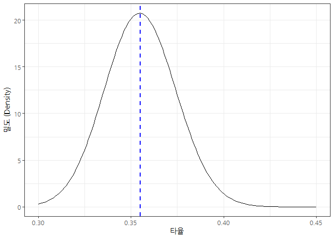

```r
## 2.2. 사전분포 최고타자 베타분포 모수추정 ------------------------
alpha_beta <- MASS::fitdistr(hitter_tbl$"타율", dbeta,
                    start = list(shape1 = 560, shape2 = 970))

alpha0 <- alpha_beta$estimate["shape1"]
beta0 <- alpha_beta$estimate["shape2"]

## 2.3. 최고타자 사전분포 시각화 ------------------------
gg_x <- seq(0.3, 0.45, .001)
beta_dens <- dbeta(gg_x, alpha0, beta0)

beta_df <- data.frame(gg_x, beta_dens)

beta_df %>%
  ggplot(data = ., aes(x=gg_x, y=beta_dens)) +
    geom_line() +
    scale_x_continuous(limits=c(0.3, 0.45)) +
    theme_bw(base_family="NanumGothic") +
    theme(legend.position = "top") +
    scale_color_brewer(palette="Dark2") +
    labs(x="타율", y="밀도 (Density)") +
    geom_vline(aes(xintercept=alpha0/(alpha0+beta0)),
               color="blue", linetype="dashed", size=1)
```

### 2.4. 장효조, 김태균 타율 사후분포

사후분포 타율을 추정하는 방식은 4가지를 제시하고 있다.

- 모의시험 시뮬레이션 (Simulation)
- 수치적분 (Numerical Integration)
- 닫힌 공식 해법 (Closed-form Solution)
- 닫힌 공식 정규분포 근사화 (Closed-form approximation)

4가지 접근방법 모두 장단점이 있다.

#### 2.4.1. 모의시험 시뮬레이션 (Simulation)

모의시험은 수식이나 기타 다른 설명이 없이 컴퓨터가 열심히 일을 해서 정답을 가져다 주는 것이니 그냥 가져다 쓰면된다.

```r
# 3. 최고 타자는 누구인가? ------------------------------
ab_eb_df <- ab_df %>%
  mutate(eb_estimate = (안타 + alpha0) / (타수 + alpha0 + beta0)) %>%
  mutate(alpha1 = 안타 + alpha0,
         beta1 = 타수 - 안타 + beta0)

## 3.1. 모의시험 시뮬레이션 ------------------------------

chj_param <- ab_eb_df %>% dplyr::filter(이름 =="장효조") %>%
  dplyr::select(alpha1, beta1)
chj_sim <- rbeta(1e6, chj_param$alpha1, chj_param$beta1)

ktg_param <- ab_eb_df %>% dplyr::filter(이름 =="김태균") %>%
  dplyr::select(alpha1, beta1)
ktg_sim <- rbeta(1e6, ktg_param$alpha1, ktg_param$beta1)

(sim_res <- mean(chj_sim > ktg_sim))
```

```
[1] 0.782726
```

장효조, 김태균 타율 사후분포에서 1,000,000번 두 타자를 경쟁시켜 누가 더 타율이 높은지 평균을 낸다. 장효조 선수가 78.3% 더 타율이 높게 나온다.

#### 2.4.2. 수치적분

두번째 방법은 수치적분을 사용한 방식으로 A/B 검정이 많이 사용되어 [Agile A/B testing with Bayesian Statistics and Python](https://web.archive.org/web/20150419163005/http://www.bayesianwitch.com/blog/2014/bayesian_ab_test.html)에서 영감을 받아 David Robinson이 구한현 방식이다. 모수 $\alpha , \beta$가 큰 경우 시간이 다소 걸린다는 점을 주의한다.

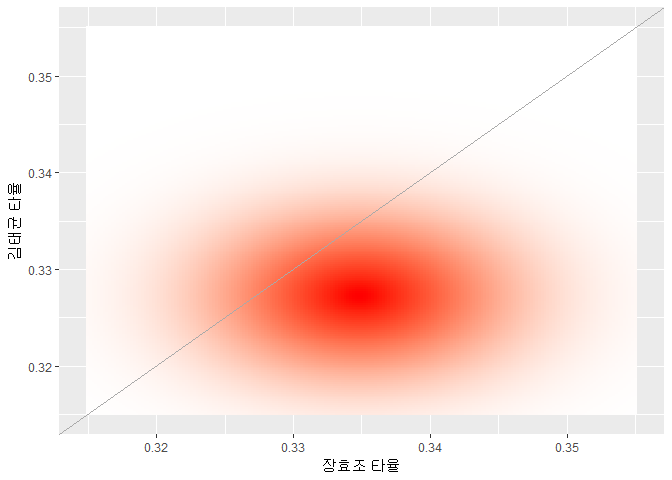

```r
## 3.2. 수치 적분 ------------------------------
x <- seq(.315, .355, .0002)

crossing(chj_x = x, ktg_x = x) %>%
  mutate(chj_density = dbeta(chj_x, chj_param$alpha1, chj_param$beta1),
         ktg_density = dbeta(ktg_x, ktg_param$alpha1, ktg_param$beta1),
         joint = chj_density * ktg_density) %>%
  ggplot(aes(chj_x, ktg_x, fill = joint)) +
  geom_tile() +
  geom_abline(color="darkgray") +
  theme_bw(base_family="NanumGothic") %>%
  scale_fill_gradient2(low = "white", high = "red") +
  labs(x = "장효조 타율",
       y = "김태균 타율",
       fill = "결합 밀도") +
  theme(legend.position = "none")
```

```r
d <- .00002
limits <- seq(.315, .55, d)
sum(outer(limits, limits, function(x, y) {
  (x > y) *
    dbeta(x, chj_param$alpha1, chj_param$beta1) *
    dbeta(y, ktg_param$alpha1, ktg_param$beta1) *
    d ^ 2
}))
```

```
[1] 0.7632884
```

#### 2.4.3. 닫힌 공식 해법(Closed-form Solution)

베이지안 A/B 검정에 대한 닫힌 공식 해법이 존재한다. 이를 반영하여 누가 더 타율이 높은지 검정한다.

즉, 장효조 선수와 김태균 선수의 타율 정보가 있을 때, 장효조 선수 타율이 김태균 선수 타율보다 높을 확률을 다음과 같이 정의할 수 있다. 즉, A가 B보다 나을 확률은 [Miller 해법](http://www.evanmiller.org/bayesian-ab-testing.html#binary_ab_derivation)에 따라 다음과 같이 계산할 수 있다.

$$p_A \sim \mbox{Beta}(\alpha_A, \beta_A)$$

$$p_B \sim \mbox{Beta}(\alpha_B, \beta_B)$$

$${\rm Pr}(p_B > p_A) = \sum_{i=0}^{\alpha_B-1}\frac{B(\alpha_A+i,\beta_A+\beta_B)}{(\beta_B+i) B(1+i, \beta_B) B(\alpha_A, \beta_A) }$$

여기서 $B$는 베타함수가 된다. A/B 검정에서 많이 사용되는 베이지안 사전분포는 베타분포고, 응답율을 이항분포를 가정할 경우, 사후분포는 베타분포가 되고 모수는 다음과 같다.

$$~ Beta (\alpha + s, \beta + n - s)$$

- $\alpha:$ 베타분포 첫번째 모수
- $\beta:$ 베타분포 두번째 모수
- $n:$ 시행 횟수
- $s:$ 성공 횟수

```r
## 3.3. 닫힌 공식 해법(Closed-form Solution) -----------------------------

h <- function(alpha_a, beta_a,
              alpha_b, beta_b) {
  j <- seq.int(0, round(alpha_b) - 1)
  log_vals <- (lbeta(alpha_a + j, beta_a + beta_b) - log(beta_b + j) -
                 lbeta(1 + j, beta_b) - lbeta(alpha_a, beta_a))
  1 - sum(exp(log_vals))
}

h(chj_param$alpha1, chj_param$beta1,
  ktg_param$alpha1, ktg_param$beta1)
```

```
[1] 0.7816925
```

마지막 방법은 [John D. Cook(2012), Fast approximation of Beta inequalities](http://www.johndcook.com/fast_beta_inequality.pdf) 방법을 활용한 것으로, 모수 $\alpha , \beta$가 큰 경우 베타분포가 정규분포로 근사되어 차이가 크게 나지 않는 성질을 활용하는 방법이다. 반대로 모수 $\alpha , \beta$가 작은 경우 적합이 잘 되지 않아 오차가 크게 날 수 있으니 주의한다.

```r
## 3.4. 닫힌 공식 정규분포 근사화(Closed-form approximation) -----------------------------
h_approx <- function(alpha_a, beta_a,
                     alpha_b, beta_b) {
  u1 <- alpha_a / (alpha_a + beta_a)
  u2 <- alpha_b / (alpha_b + beta_b)
  var1 <- alpha_a * beta_a / ((alpha_a + beta_a) ^ 2 * (alpha_a + beta_a + 1))
  var2 <- alpha_b * beta_b / ((alpha_b + beta_b) ^ 2 * (alpha_b + beta_b + 1))
  pnorm(0, u2 - u1, sqrt(var1 + var2))
}

h_approx(chj_param$alpha1, chj_param$beta1,
         ktg_param$alpha1, ktg_param$beta1)
```

```
[1] 0.7822859
```

4가지 분석결과 모두 장효조 선수가 김태균 선수와 동시대 경쟁을 할 경우 거의 80% 정도 장효조 선수 타율이 김태균 선수 타율보다 높게 나올 것으로 추정된다.

[^1]: [Understanding Bayesian A/B testing (using baseball statistics)](http://varianceexplained.org/r/bayesian_ab_baseball/)